# Series temporales en R

Fernando Villalba Bergado

24 de abril de 2018

# 1 INTRODUCCIÓN

Este manual describe cómo trabajar con series temporales y cómo hacer pronósticos con ellas en R. Explicaremos los principales paquetes de
$$R$$
que facilitan el uso de series temporales y muchos ejemplos prácticos que muestran casos concretos de análisis, aplicaciones y programación sobre datos temporales en este lenguaje.

Una serie temporal es una secuencia de datos, observaciones o valores, medidos en determinados momentos y ordenados cronológicamente. Los datos pueden estar espaciados a intervalos iguales o irregulares, normalmente las series sobre las que trabajaremos son series de intervalo regular, pues son las más fáciles de representar y analizar con funciones y librerías..

Las series temporales son pares de valores fecha-dato y uno de los usos principales es su análisis para predicción y pronóstico (así se hace por ejemplo con los datos climáticos, las acciones de bolsa, o las series de datos demográficos).

Las series que utilizamos habitualmente son **univariadas*, lo que quiere decir que los datos se corresponden con observaciones secuenciales sobre intervalos de tiempo iguales (un dato al año, al día , hora). Si el tiempo entre observaciones es igual siempre, el tiempo no es necesario en los datos aunque esté implicito en ellos, y solo necesitamos una fecha inicial.

## 1.1 Clasificación de las series temporales

Existen muchas formas de clasificar las series temporales, cada vez que clasificamos algo pretendemos identificar patrones, grupos comunes que nos aporte información del comportamiento de los datos. Una vez identificado el grupo, nos permite focalizar y realizar un mejor análisis más orientado y eficaz.

Visualizar los datos es el punto de partida de cualquier análisis, porque en la gráfica se aprecian de forma intuitiva las caracteristicas de las series y se determina de manera natural la estructura de la serie, enfocando el análisis.

Existen muchas características de las series temporales, vamos a ver algunas de ellas que incluso son complementarias y yuxtapuestas, pero que se entienden mejor al comparar con su par inverso:

### 1.1.1 Tendendcia - ciclo - aleatoriedad

Una forma de ver las caracteristicas de una serie temporal es según estas tres caracteristicas, que se pueden dar deforma aditiva sobre una misma serie:

```
1. **Series de tendencia.** Son aquellas que tienen una evolución creciente o decreciente en el tiempo.
2. **Series estacionales** Son las que reflejan comportamientos de patrones periódicos asociados al calendario, o formas que se repiten en horas tiempos fijos. Las **Series Cíclicas.** serían las que tienen patrones de repetición que no se corresponden con calendarios fijos, se repiten en ciclos irregulares, mucho más difíciles de predecir.
4. **Series aleatorias**. Son las que no se pueden predecir, las que son equivalentes a ruido blanco.
```

En las series estacionales, podemos pronosticar las temporadas de picos y valles, pero en las series cíclicas es algo más complicado pues la repetición del ciclo no es previsible por calendario. También interesa apreciar en los datos si existe una tendencia de fondo, de forma que pueda extraerse de los datos y aplicar diferentes modelos de predicción a cada uno de los componentes que forman la serie de observaciones.

Lo habitual es que una serie temporal sea mezcla y convinación de estos comprotamientos (tendencia + estacionalidad + ruido), identificarlos facilitará el trabajo de análisis.

Existen funciones en R que descomponen una serie temporal
$$X_t$$
en los 3 componentes principales
$$X_t=T_t+E_t+A_t$$
(tendencia + estacionalidad + ruido). Una de estas funciones es `sdl()` del paquete base y también la función `decompose()`.

[figure not shown]

descomposición de la serie de precios del oro

```r
    require(forecast) # la serie ejem: gold está en esta libreria

    # Aplicamos funcion de descomposición sdl()
    des.oro<-stl(gold,s.window = "periodic" )
    #Pintamos el resultado
    plot(des.oro, main="Descomposición del precio del oro")
    #plot(decompose(gold))
```

### 1.1.2 Estacionariedad

Esta característica de las series incica si sus propiedades cámbian o no cambian con el tiempo, es decir si por ejemplo la media, la varianza o la covarianza son constantes en la serie o por el contrario cambian a lo largo de las observaciones de forma significativa. En resumen, una serie estacionaria es aquella cuyas propiedades (media, varianza, covarianza) no dependen del periodo de observación en el que se miden.

No confuncir con estacional con estacionario, pues son conceptos diferentes, uno indica ciclos y el otro es una propiedad de los datos.

La *estacionariedad* es una propiedad muy importante, pues existen muchos análisis matemáticos que describen muy bien las series estacionarias, y no tan bien las que no lo son, de hecho los modelos estadisticos de pronóstico de series temporales **sólo sirven para series estacionarias**.

Existen métodos que veremos para transformar una serie no estacionaria en otra que si lo es, y por tanto sobre la que podemos aplicar pronosticos estadísticos con armamento de análisis potente y fundamentado. Recordemos también que los modelos de pronostico no solo pueden ser estadisticos, hay cientos de modelos físicos y basados en otros conceptos que si funcionan con las series no estacionarias.

La estacionariedad puede darse en unas propiedades y no darse en otras, por lo que las transformaciones serán solo en la dirección que interese. La estacionariedad de la varianza, por ejemplo, se denomina **homoestacidad**.

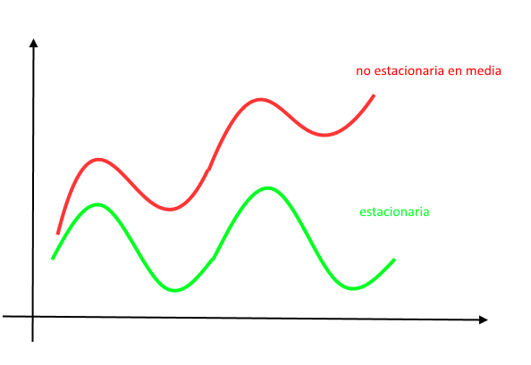

Ejemplo de estacionariedad en la media

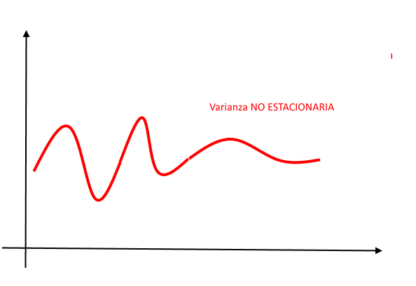

Ejemplo de estacionariedad en la varianza

Las series estacionales pueden abordarse, además de por los sistemas estadísticos, por otros métodos como el **análisis espectral** o de frecuencias. Consisten estos sistemas en la aplicación de la *transformada de Fourier* a los datos para descomponer la serie en combinación lineal de funciones trigonométricas (suma de funciones seno y coseno).

Las graficas asociadas a los métodos espectrales son el periodograma o espectro de frecuencias que está relacionado con la grafica de autocorrelación. En el ejemplo siguiente se analizan las graficas ACF y el periodograma de la serie de manchas solares anual, y como se ve el perido de maxima autocorrelación de la gráfica de ACF que se corresponde con una retraso de 10 años, es equivalente a la frecuencia máxima del espectro de frecuencias en tormo a 0,1 (
$$1/0,1=10$$
)

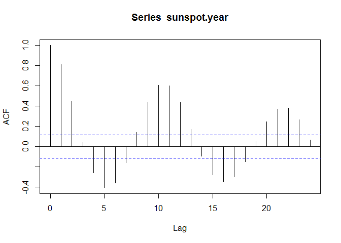

```r
    acf(sunspot.year)
```

```r
    spectrum(sunspot.year)
```

[figure not shown]

```r
    # periodogram(sunspot.year)
```

### 1.1.3 Autocorrelación

La autocorrelación (ACF) es una medida de la dependencia de los valores actuales respecto de los pasados en una serie temporal. Es una propiedad muy importante cuando se evalua para diferentes peridos de retardo en las graficas de autocorrelación que se generan con la fucnión `acf()`. Cuando los valores son cercanos a 1 indica una relación lineal entre los valores pasado y futuros, si es cero es que no existe relación (lineal) apreciable y si es es -1 es que la dependencia es inverssamente lineal.

### 1.1.4 Ruido blanco

Se llama ruido blanco a una serie temporal completamente aleatoria **impredecible**, cuyas observaciones son independientes y están idénticamente distribuidas en el tiempo, con media cero y varianza constante.

Cuando hacemos la suma acumulada de una serie de observaciones de *ruido blanco* se nos genera lo que denominamos un *camino aleatorio* ( *randow walk*).

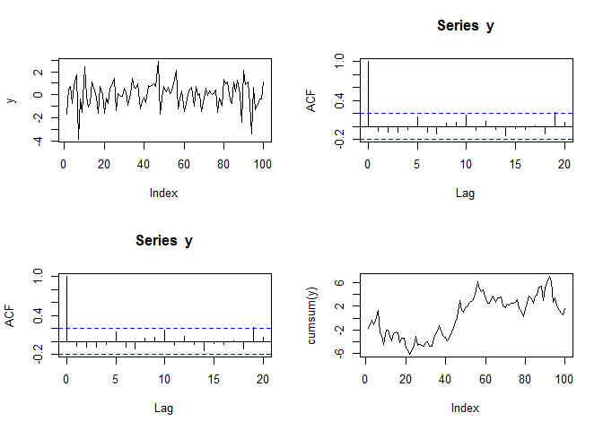

```r
    # Generamos ruido blanco
    y<-rnorm(100)
    par(mfrow=c(2,2))
    # pintamos la serie de ruido blanco
    plot(y, type="l")
    plot(acf(y)) # pintamos la grafica de autocorrelaciones
    # pintamos la serie de camino aleatorio
    plot(cumsum(y),type="l")
```

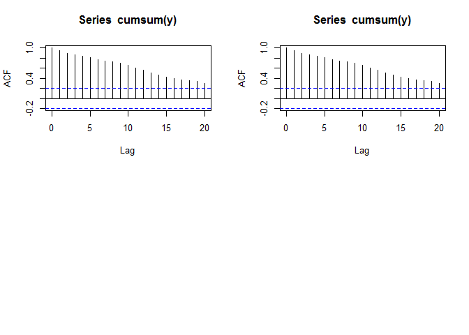

```r
    plot(acf(cumsum(y)))
```

Existe una prueba denominada test de *Ljung-Box* que nos sirve para determiar si una serie temporal se comporta como ruido blanco o no. Si el resultado de `p` es un valor mayor que *0.05* se sugiere que los datos no son significativamente diferentes del ruido blanco, y si es inferio es posible que los datos sean predecibles pues se diferencian del ruido blanco, no son observaciones completamente independientes. Veremos esto en detalle en siguientes capítulos

## 1.2 Estructura del libro

Se ha ordenado el manual en un formato progresivo, de manera que sirva de libro de consulta constante durante el trabajo y también de guia continua de aprendizaje, desde las nociones básicas, a las más complejas.

En primer lugar haremos un resumen completo de las formas de medida del tiempo en R, lo que nos permitirá entender mejor el funcionamiento de las series temporales, así como obtener conocimientos para realizar analisis alternativos, no solo con objetos de serie temporal sino con otras muy comunes como `data frame`.

El segundo capítul está dedicado a obtener datos, a crear series temporales para ejemplos, o a obtenerlas de los multiples origenes que puedan darse (web, ficheros…). Se aportan ejemplos concretos de librerías para descarga de datos financieros que son unos datos muy demandados por ususarios de
$$R$$
.

En el tercer capítulo entramos al grano describiendo cómo realizar gráficos de series temporales, haremos un completo repaso por las multiples funciones que existen, y que son más fáciles y atractivas. También se detallan tipos de graficos exclusivos de series temporales y que realizan analisis graficos muy completos, como los graficos estacionales, los de autocorrelación y retardo ect.

El cuarto capitulo está dedicado a las funciones de pronostico más simples y una introducción al completo paquete `forecast`que tiene elementos interesantes para los pronósticos.

El siguiente caitulo se muestra una introducción al analisis de los residuos, que es una forma de evaluar la bondad de las predicciones que realizamos con los modelos de pronostico.

El sexto capitulo se entra en los metodos de pronostico por regresiñon lineal.

El séptimo detalla las transformaciones en los datos, y cómo se pueden conseguir con ellas mejores pronósticos con simples cambios de base de los datos.

# 2 MEDIDA DEL TIEMPO EN R

Antes de iniciarnos en el uso de series temporales vamos realizar un resumen de la medida del tiempo en R, qué clases existen, cómo se trabaja con fechas y datos de tiempo. Conocer estos tipos de datos no es imprescindible en el manejo de series temporales, pero nos permite tener un conocimiento profundo y mucho más completo de la teoría.

Los datos de tiempo (fechas y horas) son tratados en R Base mediante varios tipos de datos, objetos y clases. Estas clases almacenan internamente la fecha como el número de días o segundos transcurridos desde el 1 de enero de 1970 en la zona UTC.

R Base define principalmente 3 clases de datos fechados:

1. Clase *Date* para las fechas diarias de calendario
2. Para las fechas horarias se usan dos clases:
   - **POSIXct** es un **valor** numérico que representa el número de segundos desde 1/1/1970.
   - **POSIXlt** es un objeto **lista** con distintas variables (sec,min,hour,mday,mon, year, wday, yday, isdst, zone, gmtoff)

### 2.0.1 Fecha diarias (Dates)

La clase `Dates` almacena solo datos *diarios* que incluyen el año, mes y día de una fecha, pero no los tiempos inferiores a un día (ni horas, ni segundos por ejemplo).

Un fecha del tipo *Date* se puede asignar mediante código de la siguiente manera:

```r
  # Asignar una fecha
  x<- as.Date("1970-01-03")
  x  # se imprime como cadena de texto
```

```
## [1] "1970-01-03"
```

```r
  # pero podemos comprobar que internamente se almacena como 2
  # dos días despues del 1 de enero de 1970.
  unclass(x)
```

```
## [1] 2
```

### 2.0.2 Fechas completas `POSIXct` y `POSIXlt`

R almacena las fechas completas usando los estándar *POSIX* que incluyen una serie de características para homogeneizar el tipo complejo de datos de tiempos en diferentes sistemas operativos. POSIX es el acrónimo de *Portable Operating System Interface* y la X procede del sistema operativo
$$\UNIX$$
.

Ambas clases *POSIX* almacenan la fecha y hora como el número de segundos transcurridos desde el *1 de enero de 1970*. La clase `POSIXct` almacena internamente esta cifra como un número entero, mientras que la clase `POSIXlt` la descompone en una lista con elementos para los segundos, minutos, horas, día, mes y año.

En resumen:

```
-  **POSIXct** es simplemente un numero entero que guarda el número de segundos desde 1/1/1970. Es útil cuando almacenamos tiempos en un data frame, pues ocupa menos espacio y solo una variable.
-  **POSIXlt** es un objeto lista que almacena un bloque completo de información diferenciada, como el día, año, dia de la semana, día del mes etc.
```

Para recordar la diferencia es util la nemotecnia de que el que finaliza en lt es una lista (`POSIXlt` $\rightarrow$ lt = lista, `POSIXct` = entero)

### 2.0.3 librería `lubridate` funciones para fechas

Para trabajar con fechas y horas es casi imprescindible cargar la librería `lubridate`. Este paquete nos facilita el uso analitico de los datos fechados:

- `Sys.Date()` $\rightarrow$ fecha actual del sistema operativo
- `now()` $\rightarrow$ fecha y hora del momento actual
- `today()` $\rightarrow$ fecha `Date` de hoy
- `weekdays()` $\rightarrow$ devuelve el día de la semana
- `months()` $\rightarrow$ retorna el mes de la fecha
- `quarters()` $\rightarrow$ retorna el cuatrimestre de la fecha (Q1,Q2,Q3 o Q4)

Otras funciones que permiten operaciones de tiempo son:

- `difftime(fecha1, fecha2, units = "weeks")` $\rightarrow$ la diferencia en tiempo entre dos fechas.
- `diff()` $\rightarrow$ aplicado a una serie temporal da la diferencia entre dos valores consecutivos de fecha.
- `seq(dia.inicio, dia.fin,length=10, by=2)`$\rightarrow$ crea una secuencia de fechas.

Una forma alternativa y útil para acceder a un valor concreto dentro de una fecha (por ejemplo el año, el día de una fecha) es hacer la llamada a las propiedades de la variable usando el símbolo `$` en la forma `varfecha$mday`:

- `sec`: segundos
- `min`: minutos de la fecha
- `hour`: hora
- `mday`: dia del mes
- `mon`: mes
- `year`: año desde 1900. Por lo que debemos sumar esto si queremos el año real
- `wday`: día de la semana (0 domingo - 6 sábado)

Veamos un ejemplo práctico:

```r
  # guardamos la fecha actual del sistema en x
  x <- Sys.time()
  x
```

```
## [1] "2018-07-12 14:56:16 CEST"
```

```r
  # Convertimos es fecha en la clase POSIXlt (la más completa con la lista)
  fecha_x <- as.POSIXlt(x)
  # imprimimos los nombres de las variables de la clase POSIXlt
  names(unclass(fecha_x))
```

```
##  [1] "sec"    "min"    "hour"   "mday"   "mon"    "year"   "wday"
##  [8] "yday"   "isdst"  "zone"   "gmtoff"
```

```r
  # Para sacar el dato de cualquiera de ellos basta escribir:
  #  nombre del objeto + $ nombre_variable
  fecha_x$sec
```

```
## [1] 16.19421
```

```r
  fecha_x$wday
```

```
## [1] 4
```

```r
  # cambiamos el objeto a POSIXct
  fecha_x<-as.POSIXct(fecha_x)
  unclass(fecha_x)
```

```
## [1] 1531400176
## attr(,"tzone")
## [1] ""
```

```r
  #solo almacena este gran entero con los segundos desde 1/1/1970

  # Generamos una secuencia de días
  dia1=as.Date("25/05/2017",format="%d/%m/%Y")
  dia2=as.Date("10/06/2017",format="%d/%m/%Y")
  seq(dia1,dia2, by=1)
```

```
##  [1] "2017-05-25" "2017-05-26" "2017-05-27" "2017-05-28" "2017-05-29"
##  [6] "2017-05-30" "2017-05-31" "2017-06-01" "2017-06-02" "2017-06-03"
## [11] "2017-06-04" "2017-06-05" "2017-06-06" "2017-06-07" "2017-06-08"
## [16] "2017-06-09" "2017-06-10"
```

```r
  seq(dia1,length=10,by=1)
```

```
##  [1] "2017-05-25" "2017-05-26" "2017-05-27" "2017-05-28" "2017-05-29"
##  [6] "2017-05-30" "2017-05-31" "2017-06-01" "2017-06-02" "2017-06-03"
```

```r
  seq(dia1,dia2, by="week")
```

```
## [1] "2017-05-25" "2017-06-01" "2017-06-08"
```

### 2.0.4 Conversión de texto a fecha `strptime`

Cuando el formato de partida que contiene la fecha es un texto, la función *strptime()* es una manera sencilla de convertirlo en la clase de tiempo, es decir pasar una cadena en formato texto a la clase `POSIX`. La función toma como parámetros de entrada la lista de texto con las fechas y también hay que decirle qué formato tienen dichos textos de entrada.

```r
  # Convertir texto en fecha
  # Ejemplo 1
  x <- c("1 ene 1960 12:37", "2 abr 1990 23:00", "7 jul 1975 15:15")
  # para convertir estos textos con fechas a formato de tiempo de R
  z <- strptime(x, "%d %b %Y %H:%M")
  z
```

```
## [1] "1960-01-01 12:37:00 CET"  "1990-04-02 23:00:00 CEST"
## [3] "1975-07-07 15:15:00 CET"
```

```r
  class(z)
```

```
## [1] "POSIXlt" "POSIXt"
```

```r
  #ahora podemos acceder a los datos de esta forma sencilla
  z$year # nos da el año
```

```
## [1] 60 90 75
```

```r
  z$mon  # nos devuelve el mes
```

```
## [1] 0 3 6
```

```r
  z$wday # nos devuelve el día de la semana
```

```
## [1] 5 1 1
```

```r
  z$mday # devuelve el día del mes
```

```
## [1] 1 2 7
```

```r
  # Ejemplo 2 . cambiamos el formato de entrada
  x <- c("1/1/60 12:37", "2/4/90 23:00", "7/7/75 15:15")
  z <- strptime(x, "%d/%m/%y %R") # notese el cambio de formato
  z
```

```
## [1] "2060-01-01 12:37:00 CET"  "1990-04-02 23:00:00 CEST"
## [3] "1975-07-07 15:15:00 CET"
```

### 2.0.5 Operaciones con fechas y tiempos

Podemos realizar operaciones con fechas y tiempos siempre que los objetos que intervengan pertenezcan a la misma clase. Es decir, un objeto *Date* no puede sumarse a otro *POSIXlt*, debemos primero convertirlos a la misma clase.

```r
  x<- as.Date("2015-03-24")
  y <-as.POSIXlt("2016-03-24 12:10")

  # probamos a restar dos objetos de diferentes clases
  # y-x # esto da error

  # Convertimos x a clase POSIXlt
  x<-as.POSIXlt(x)
  y-x
```

```
## Time difference of 366.4653 days
```

```r
  # ahora la resta es posible
```

Los objetos POSIX tienen una propiedad que permite especificar la zona horaria en la forma `y<-as.POSIXct("2016-03-24 12:10", tz="GMT")`

### 2.0.6 Funciones adicionales de `lubridate`

Este paquete añade funciones que facilitan la manipulación de fechas expresadas en la clase POSIXct. La conversión de caracteres a dicha clase puede hacerse utilizando las funciones definidas por combinaciones de las letras d, m, y (day, month, year) y h, m, s (horas, minutos y segundos).

Este sistema facilita la entrada de datos a R, por ejemplo $dmy_hms$ espera *día-mes-año-horas-minutos-segundos* en ese orden; si usamos $ymd_h$ espera *año-mes-dia-hora* en el mismo orden

Veamos un ejemplo:

```r
  require(lubridate)
  library(lubridate)

  fecha1=ymd_hms("2016-02-23 18:15:09")
  fecha1
```

```
## [1] "2016-02-23 18:15:09 UTC"
```

```r
  fecha2=dmy_hm("12/3/1975 23:24")
  fecha2
```

```
## [1] "1975-03-12 23:24:00 UTC"
```

```r
  fecha3=dmy("6 7 1975")
  fecha3
```

```
## [1] "1975-07-06"
```

```r
  # Extraemos valores de mes, semana, y día de la semana de fechas
  month(fecha2)
```

```
## [1] 3
```

```r
  week(fecha3)
```

```
## [1] 27
```

```r
  wday(fecha3)
```

```
## [1] 1
```

### 2.0.7 Extraer información de un fecha

Para obtener una información concreta de una fecha u hora se utilizan las funciones, second(), minute(), hour(), day(), wday(), yday(), week(), month(), year() y tz(), para la zona horaria.

```r
  fecha.actual<-now()

  # Extraemos información de dicha fecha
  year(fecha.actual) # año
```

```
## [1] 2018
```

```r
  month(fecha.actual) # mes
```

```
## [1] 7
```

```r
  wday(fecha.actual,label = TRUE) # dia de la semana
```

```
## [1] jue
## Levels: dom < lun < mar < mié < jue < vie < sáb
```

```r
  minute(fecha.actual) # minutos
```

```
## [1] 56
```

### 2.0.8 Aritmétrica con fechas y horas

La suma de fechas con `lubridate` se hace usando la función *difftime(fecha1,fecha2, units=“days”)*, en units podemos especificar la unidad de fecha para el resultado entre las siguientes:“auto”, “secs”, “mins”, “hours”, “days”, “weeks”

```r
  d1 <- as.Date("01 marzo 1950", "%d %B %Y")
  d2 <- as.Date(c("01 abril 1955", "01 julio 1980"), "%d %B %Y")

  difftime(d2,d1,units = "weeks")
```

```
## Time differences in weeks
## [1]  265.2857 1582.8571
```

También pueden ser tratadas en R como una nueva clase de objeto que se llama intervalo.

```r
  # hay que cargar el paquete lubridate
  require("lubridate")
  # Creamos un intervalo
  congreso_inicio <- ymd_hm("20170528 12:00")
  congreso_fin <- ymd_hm("20170604 10:00")
  duracion_congreso <-  difftime(congreso_fin,congreso_inicio)
  # Para verlo en unidades enteras de fecha es mejor pasarlo a periodo
  as.period(duracion_congreso)
```

```
## [1] "6d 22H 0M 0S"
```

```r
  # Si no solo queremos la diferencia de fechas sino usarlo como intervalo
  # tenemos que crear el objeto
  duracion_congreso <- interval(congreso_inicio,congreso_fin)
  # Tambien podía definirlo así:
  congreso_inicio %--% congreso_fin
```

```
## [1] 2017-05-28 12:00:00 UTC--2017-06-04 10:00:00 UTC
```

```r
  # Ejem. tengo programada una visita a Madrid en la fecha
  visita_Madrid<-ymd("20170601")
  # quiero saber si coincide con el congreso
  visita_Madrid %within% duracion_congreso
```

```
## [1] TRUE
```

```r
  # Cual es la duración del congreso en días
  duracion_congreso / days(1)
```

```
## [1] 6.916667
```

```r
  # y en semanas
  duracion_congreso / weeks(1)
```

```
## [1] 0.9880952
```

Para convertir entre intervalos, duraciones o periodos se usan las funciones `as.interval()`, `as.period()`, y `as.duration()`.

Con la aritmética simple podemos generar series temporales de manera sencilla añadiendo o sustrayendo periodos de tiempo a una fecha:

```r
  # Inicio de la serie el 15 de mayo de 2017
  inicio<-dmy_hm("15052017 10:00")
  # Sumamos una semana 4 veces
  serie <- inicio + weeks(0:4)
  serie
```

```
## [1] "2017-05-15 10:00:00 UTC" "2017-05-22 10:00:00 UTC"
## [3] "2017-05-29 10:00:00 UTC" "2017-06-05 10:00:00 UTC"
## [5] "2017-06-12 10:00:00 UTC"
```

# 3 OBTENER DATOS

Para empezar y aprender necesitamos datos y ejemplos sencillos en los que podamos manipular y probar el código. En este capitulo mostraremos algunas de las formas de obtener datos de series temporales de manera que podamos iniciar nuestra práctica con elementos reales.

Solo vamos a describir de forma breve solo algunas de las fuentes de datos. En primer lugar los propios datos de R base, que tiene bastantes, y después muchas librarías y funciones útiles para descarga de datos de series web. Otra forma es crear los datos uno mismo, por ello explicaremos también de forma sencilla cómo crear series de prueba aleatorias para uso de enseñanza y aprendizaje.

## 3.1 Datos ejemplo en R base

El programa básico de R contienen un montón de datos de ejemplo que podemos usar en la práctica. Estos datos están contenidos en el paquete `datasets` y contiene ejemplos de multiples formatos: data frames, series ts, matrices, vectores.

Para ver todos los datos disponibles hay que ejecutar el comando `data()` en R, así conseguimos que nos muestre una lista completa de todos los objetos de datos almacenados de ejemplo. Entre estos hay varios de series temporales.

Por ejemplo usaremos los datos de *Nile* que contiene observaciones de caudal máximo del río Nilo para este primer script.

```r
    # Ejemplos de datos en datasets:
    # Serie de caudales del Nilo
    str(Nile) # vemos qué contiene Nile
```

```
##  Time-Series [1:100] from 1871 to 1970: 1120 1160 963 1210 1160 1160 813 1230 1370 1140 ...
```

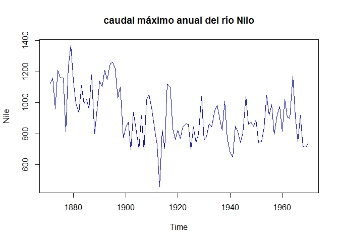

```r
    plot(Nile, main="caudal máximo anual del río Nilo", col="blue") # pintamos la serie temporal
```

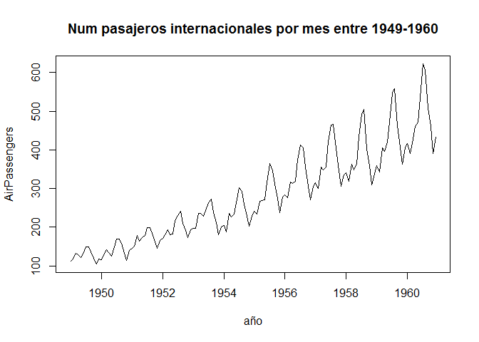

```r
    # Otro ejemplo de R Base es AirPassengers
    plot.ts(AirPassengers, main="Num pasajeros internacionales por mes entre 1949-1960", xlab="año" )
```

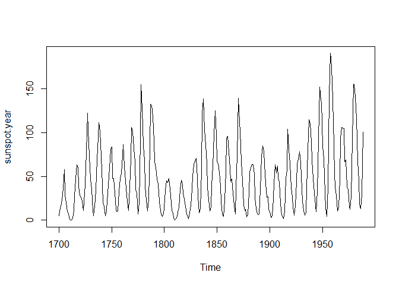

```r
    # datos de manchas solares, diarios, mensuales y anuales
    #plot(sunspot.month)
    plot(sunspot.year)
```

Muchas de las librarias relacionadas con los datos contienen ejemplos incluídos en el código del paquete. La libraría `forecast`que usaremos profusamente en este manual tiene varias series temporales de diferentes características que pueden usarse de ejemplo (gold, WWWusage…)

### 3.1.1 Resumen de datos temporales de ejemplo

[output not shown]

## 3.2 Lectura de ficheros locales

Otra opción simple es la lectura de ficheros locales, como hojas excel o ficheros `csv`. Recordamos en un ejemplo cómo realizar la lectura de un fichero.

```r
    # Lectura de ficheros separados por comas:
    datos<-read.csv("filename.txt", header = FALSE)

    # Lectura de ficheros separados por tab
    datos<-read.table("filename.txt", sep="\t", header = FALSE)

    # Por defeco se lee columnas de texto como factores, pero si no queremos eso hacemos
    datos<-read.table("filename.txt", sep="\t", header = FALSE, stringsAsFactors = FALSE)
```

Otra opcion interesante es copiar directamnte del portapapeles o de una url web:

```r
# para leer lo copiado en el portapapeles de windwows
datos<-read.table(file="clipboard", sep="\t",header=TRUE)

# para ller de una url web
datos<-read.csv("http://mitablas/aa.csv")
```

Además siempre podemos recurrir al paquete `rio` que simplifica la importación y exportación de ficheros al máximo, con dos únicas funciones (export, import).

```r
    #install.packages("rio")
    library(rio)
    # uso de export
    export(mtcars, "coches.csv")

    # uso de import
    x <- import("coches.csv")
```

## 3.3 Lectura de datos de internet

Existen multitud de webs de *open data* en las que podemos conseguir información de calidad de administraciones y gobiernos. Normalmente hay que bucear en ellas para buscar datos, y una vez que seleccionamos o tenemos a la vista la tabla resultado nos dan la opción de *descarga de ficheros* en un formato estandar como *csv*, o *json*. Copiando estos enlaces a R podemos hacer descargas directas de los datos a nuestro sistema.

Vamos a poner un ejemplo de lectura de datos desde internet de la web de datos abiertos de la Región de Murcia (http://datosabiertos.regiondemurcia.es), es una de tantas paginas oficiales con adminstracion transparente y de volcado de datos públicos. Usaremos esta web para descargar el fichero de datos diarios de la estación meteorológica MU62 situada en la Alberca Murcia y pintar una gráfica de temperaturas máximas. Usarems el objeto temporal xts que veremos más adelante en este libro.

```r
    # leemos un fichero de datos meteorologicos obtenido de la web
    #  datosabiertos.regiondemurcia.es
    # http://datosabiertos.regiondemurcia.es/carm/catalogo/medio-ambiente/informe-meteorologico-diario-carm-anos-2000-a-2017-estacion-meteorologica-mu62

    rutafichero<-"https://datosabiertos.carm.es/odata/Agricultura/IMIDA_Diario_MU62.csv"

    # Leemos los datos en formato csv directamente desde la url anterior
    datos_meteo<-read.csv(rutafichero)
    # vemos la estructura de los datos leídos
    str(datos_meteo)
```

```
## 'data.frame':    6447 obs. of  14 variables:
##  $ fecha : Factor w/ 6447 levels "01/01/2001","01/01/2002",..: 2335 2547 2760 2972 3185 3396 3608 3820 4032 4245 ...
##  $ tmed  : num  9.6 8 7 7.7 9.3 8.8 9.4 10 8.1 8.7 ...
##  $ tmax  : num  14.3 15.1 10.5 11.7 13 15 17.8 15.7 11.6 15.4 ...
##  $ tmin  : num  6.5 2.9 4.6 4.1 6.2 4.1 3 5.3 4.7 3.5 ...
##  $ hrmed : Factor w/ 719 levels "  20.9","  21.6",..: 533 517 701 653 609 584 426 298 585 544 ...
##  $ hrmax : Factor w/ 532 levels " 28.3"," 30.2",..: 529 529 530 530 530 530 529 439 527 529 ...
##  $ hrmin : Factor w/ 697 levels "   5.2","   7.0",..: 441 292 687 618 508 441 242 282 573 372 ...
##  $ radmed: num  112.6 124 40.4 94.8 117.2 ...
##  $ radmax: num  496 520 280 442 552 526 545 518 194 517 ...
##  $ vvmed : num  0.4 0.4 0.1 0.3 0.4 0.2 0.5 0.8 0.1 0.3 ...
##  $ vvmax : num  3.1 4.2 2.2 3.1 2.9 2.5 2.9 3.8 3.1 2.5 ...
##  $ dvmed : Factor w/ 1978 levels "    5.5","   11.8",..: 1978 1978 1978 1978 1978 1978 1978 1978 1978 1978 ...
##  $ prec  : num  0.1 0 9.4 0 5.9 0.1 0.1 0 0 0 ...
##  $ eto   : Factor w/ 77 levels "    0.1","    0.2",..: 8 8 5 6 8 7 10 12 6 8 ...
```

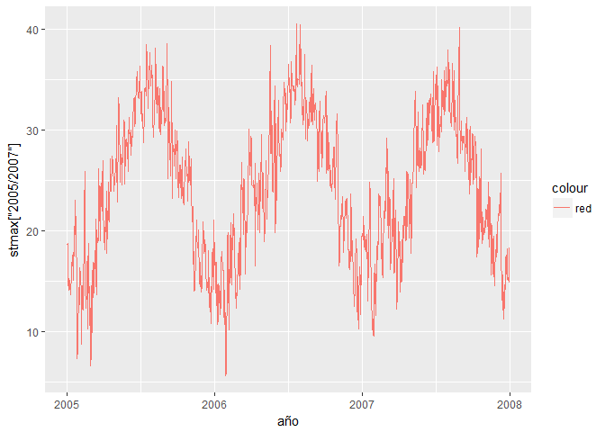

```r
    require(xts) # para objeto xts
    require(ggplot2) # para autoplot

    # creamos un objeto xts con los datos de tmax leídos
    # para crear un xts(valores, order.by=...fechas)
    stmax <- xts(datos_meteo$tmax, order.by = as.Date(datos_meteo$fecha, format = "%d/%m/%Y"))

    #Graficamos los datos del 2005 al 2008
    autoplot(stmax["2005/2007"], geom = c("line"), color="red") + xlab("año")
```

## 3.4 Crear objetos temporales `ts`

Existen varias opciones para trabajar con series temporales. La más simple es usar el objeto `ts` de R, pensado para series de tipo anual, mensual e intervalos regulares. Esta función sirve para crear y definir una serie temporal a partir de los datos, fechas y frecuencia: `y <- ts(datos, star=fecha_inicio, end= fecha_fin, frecuency=frecuencia)`. Como está pensada para datos anuales, una frecuencia de 12 indicará datos mensuales, de 4 trimestrales.

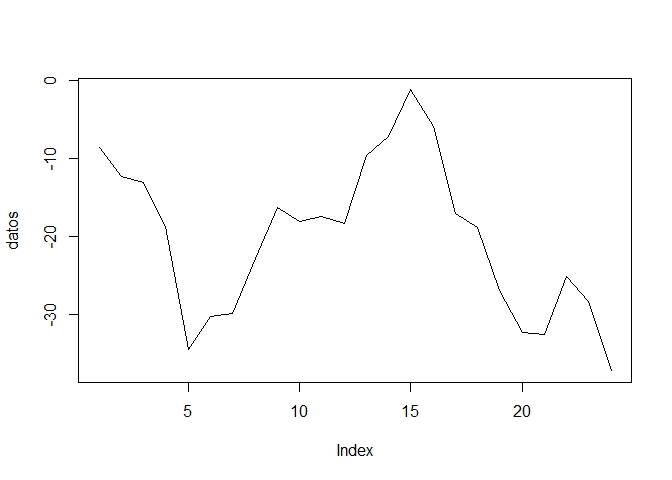

```r
    require(forecast)
    # Creamos una serie de 24 datos aleatorios para trabajar
    # como suma acumulada de una normal x10
    datos <- cumsum(rnorm(24)*10)
    # pintamos los datos
    plot(datos, type="l")
```

```r
    # Creamos la serie temporal asumiendo que son datos trimestrales (cuartos de año)
    # y que se inician en julio de 1990
    # 12= mensuales
    # 4= cada 4 meses
    mits <- ts(datos, start = c(1990,3), frequency = 4)
    mits
```

```
##            Qtr1       Qtr2       Qtr3       Qtr4
## 1990                        -8.545846 -12.213750
## 1991 -13.091255 -18.653718 -34.544790 -30.196711
## 1992 -29.837297 -22.845861 -16.232800 -18.049459
## 1993 -17.394505 -18.288586  -9.634190  -7.196923
## 1994  -1.155177  -5.785935 -17.013314 -18.869801
## 1995 -26.945030 -32.333361 -32.525540 -25.124140
## 1996 -28.351320 -37.230036
```

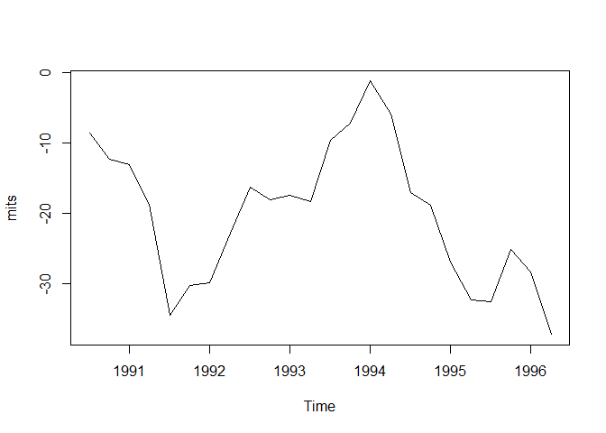

```r
    # Pintamos nuevamente los datos
    plot(mits)
```

```r
    # otra forma de ver resumen completo de la serie temporal
    tsdisplay(mits)
```

[figure not shown]

```r
    # Calculamos el maximo de la serie
     which.max(mits)
```

```
## [1] 15
```

```r
     frequency(mits)
```

```
## [1] 4
```

En el siguiente ejemplo representaremos varias series temporales en la misma escala y gráfica con la función plot.

```r
    # ejemplo para pintar varias series juntas en la misma grafica
    # Generamos 3 series aleatorias mensuales
    z <- ts(matrix(rnorm(300), 100, 3), start = c(1961, 1), frequency = 12)
    z[,2]<-z[,2]+5 # sumo 5 a la serie=col 3
    z[,3]<-z[,3]-5 # resto 5 a la serie=col 3

    class(z)
```

```
## [1] "mts"    "ts"     "matrix"
```

```r
    head(z) # as "matrix"
```

```
##             Series 1 Series 2  Series 3
## Jan 1961 -0.01918973 1.876334 -6.050900
## Feb 1961  0.15292942 3.353859 -5.155634
## Mar 1961  2.40963106 3.726643 -4.631768
## Apr 1961 -0.43204279 4.980736 -5.007940
## May 1961  0.28091097 7.926778 -6.334031
## Jun 1961 -2.51848305 5.004636 -5.121827
```

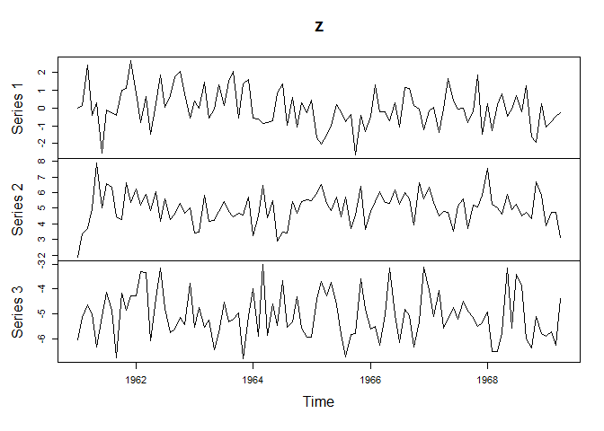

```r
    # pintamos las series con plot y con plot single
    plot(z)
```

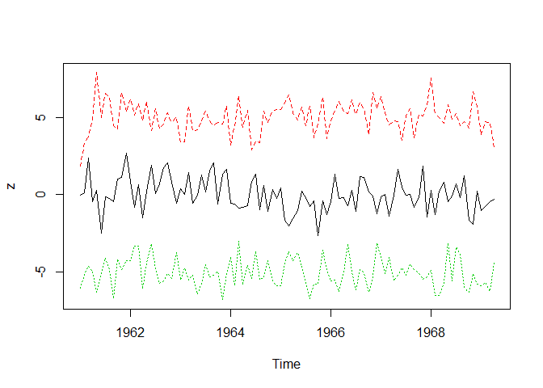

```r
    plot(z, plot.type = "single", lty = 1:3, col=c(1:3))
```

Vamos a crear también una serie temporal cíclica con números aleatorios:

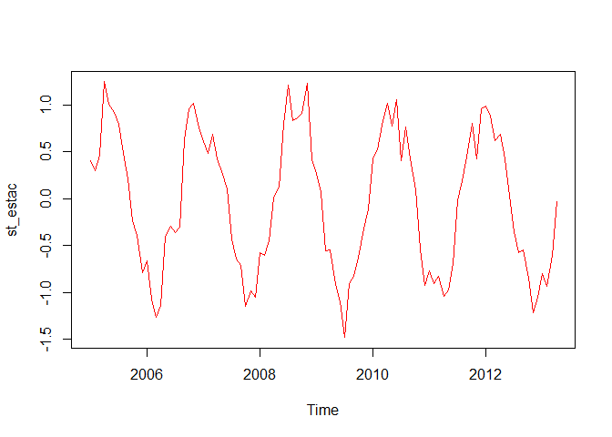

```r
    st_estac <- sin(seq(0.1*pi, 10*pi, 0.1*pi))

    # generamos una lista de 100 numero aleatorios de media 0 y standard deviation de 0.2
    err <- rnorm(length(st_estac),0, 0.2) #note: length(aSeq)=100
    st_estac <- st_estac + err


    #creating a monthly time series, beginning at January 2001
    st_estac<- ts(st_estac, freq = 12, start=c(2005,1))
    plot.ts(st_estac, col="red")
```

### 3.4.1 Dividir series temporales ts

En muchas ocasiones nos interesa extraer una parte de la serie temporal, dividir una serie para obtener dos o mas subconjuntos. Esto lo podemos hacer con la función `window()`. Veamos un ejemplo.

```r
    # ejemplo de uso de window para extraer el año 1993 de los datos
    # recordemos que son datos trimestrales (4 datos al año)
    # Usamos la serie generada en el ejmplo anterior
    ano93 <- window(mits, start = 1993, end = c(1993,4))
    ano93
```

```
##            Qtr1       Qtr2       Qtr3       Qtr4
## 1993 -17.394505 -18.288586  -9.634190  -7.196923
```

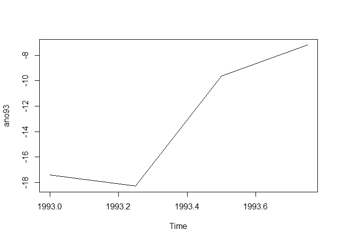

```r
    plot(ano93)
```

### Objeto `xts` Aunque existen muchos objetos creados en R para el manejo de Series temporales, es `xts` el estandar que ha permitido la gestion eficiente de las series temporales y ha conseguido aglutinar en un mismo objeto las carcerísticas comunes a todos los que necesitan implementar valores de series en el tiempo.

Uno de los defectos que encontramos en el uso de `ts` como objeto temporal es que muchas veces obtenemos datos fechados sin que tengamos necesidad de indicar el inicio y fin del periodo. Un objeto `xts` almacena los datos como `coredata` y las fechas o tiempo como `index`admitiendo una variedad amplia de formatos de tiempo. En el nucleo de un objeto `xts` está `zoo`.

En el ejemplo siguiente vermos muchas formas de usar `xts`, por ejemplo para extraer los datos de la fecha de una objeto `xts`se usa la función `index(objet_xts)`esto no ahorrará muchos dolores de cabeza buscando la forma trabajar con las fechas de la serie.

```r
    library(xts)
    # creamos de nuevo una serie aleatoria temporal
    datostem <- cumsum(rnorm(60)*10)
    datostem <- ts(datostem, start = c(2010,3), frequency = 12)

    # convertimos el objeto del ejemplo anterior mits en xts
    xts1<-as.xts(datostem)
    class(xts1)
```

```
## [1] "xts" "zoo"
```

```r
    head(xts1)
```

```
##                [,1]
## mar 2010  -7.312697
## abr 2010 -11.742784
## may 2010 -23.243811
## jun 2010 -19.193767
## jul 2010 -18.827687
## ago 2010 -30.897851
```

```r
    # La forma habitual de crear una serie xts será así:
    require(rio)
      dat.bit<-import("bitcoinity_data.csv")
      xts1 <- xts(dat.bit$price, order.by=as.Date(dat.bit$Time, "%Y-%m-%d %R"))

    # extraemos solo lo datos de xts
    head(coredata(xts1))
```

```
##            [,1]
## [1,] 0.06445989
## [2,] 0.06457231
## [3,] 0.06190290
## [4,] 0.10889928
## [5,] 0.25884091
## [6,] 0.23844714
```

```r
    # vemos el indice de tiempo almacenado en xts
    index(xts1)
```

```
##  [1] "2010-07-01" "2010-08-01" "2010-09-01" "2010-10-01" "2010-11-01"
##  [6] "2010-12-01" "2011-01-01" "2011-02-01" "2011-03-01" "2011-04-01"
## [11] "2011-05-01" "2011-06-01" "2011-07-01" "2011-08-01" "2011-09-01"
## [16] "2011-10-01" "2011-11-01" "2011-12-01" "2012-01-01" "2012-02-01"
## [21] "2012-03-01" "2012-04-01" "2012-05-01" "2012-06-01" "2012-07-01"
## [26] "2012-08-01" "2012-09-01" "2012-10-01" "2012-11-01" "2012-12-01"
## [31] "2013-01-01" "2013-02-01" "2013-03-01" "2013-04-01" "2013-05-01"
## [36] "2013-06-01" "2013-07-01" "2013-08-01" "2013-09-01" "2013-10-01"
## [41] "2013-11-01" "2013-12-01" "2014-01-01" "2014-02-01" "2014-03-01"
## [46] "2014-04-01" "2014-05-01" "2014-06-01" "2014-07-01" "2014-08-01"
## [51] "2014-09-01" "2014-10-01" "2014-11-01" "2014-12-01" "2015-01-01"
## [56] "2015-02-01" "2015-03-01" "2015-04-01" "2015-05-01" "2015-06-01"
## [61] "2015-07-01" "2015-08-01" "2015-09-01" "2015-10-01" "2015-11-01"
## [66] "2015-12-01" "2016-01-01" "2016-02-01" "2016-03-01" "2016-04-01"
## [71] "2016-05-01" "2016-06-01" "2016-07-01" "2016-08-01" "2016-09-01"
## [76] "2016-10-01" "2016-11-01" "2016-12-01" "2017-01-01" "2017-02-01"
## [81] "2017-03-01" "2017-04-01" "2017-05-01" "2017-06-01" "2017-07-01"
## [86] "2017-08-01" "2017-09-01" "2017-10-01" "2017-11-01" "2017-12-01"
## [91] "2018-01-01" "2018-02-01" "2018-03-01" "2018-04-01" "2018-05-01"
```

```r
    indexClass(xts1) # tipo de fechas usadas
```

```
## [1] "Date"
```

```r
    indexFormat(xts1) # formato de las fechas
```

```r
    tzone(xts1) # Zona Horaria
```

```
## [1] "UTC"
```

```r
    # otra forma de verlo todo a la vez es con el comando
        .index(xts1)
```

```
##  [1] 1277942400 1280620800 1283299200 1285891200 1288569600 1291161600
##  [7] 1293840000 1296518400 1298937600 1301616000 1304208000 1306886400
## [13] 1309478400 1312156800 1314835200 1317427200 1320105600 1322697600
## [19] 1325376000 1328054400 1330560000 1333238400 1335830400 1338508800
## [25] 1341100800 1343779200 1346457600 1349049600 1351728000 1354320000
## [31] 1356998400 1359676800 1362096000 1364774400 1367366400 1370044800
## [37] 1372636800 1375315200 1377993600 1380585600 1383264000 1385856000
## [43] 1388534400 1391212800 1393632000 1396310400 1398902400 1401580800
## [49] 1404172800 1406851200 1409529600 1412121600 1414800000 1417392000
## [55] 1420070400 1422748800 1425168000 1427846400 1430438400 1433116800
## [61] 1435708800 1438387200 1441065600 1443657600 1446336000 1448928000
## [67] 1451606400 1454284800 1456790400 1459468800 1462060800 1464739200
## [73] 1467331200 1470009600 1472688000 1475280000 1477958400 1480550400
## [79] 1483228800 1485907200 1488326400 1491004800 1493596800 1496275200
## [85] 1498867200 1501545600 1504224000 1506816000 1509494400 1512086400
## [91] 1514764800 1517443200 1519862400 1522540800 1525132800
## attr(,"tzone")
## [1] "UTC"
## attr(,"tclass")
## [1] "Date"
```

```r
    # nos dice el día de la semana del indice
    .indexwday(xts1)
```

```
##  [1] 4 0 3 5 1 3 6 2 2 5 0 3 5 1 4 6 2 4 0 3 4 0 2 5 0 3 6 1 4 6 2 5 5 1 3
## [36] 6 1 4 0 2 5 0 3 6 6 2 4 0 2 5 1 3 6 1 4 0 0 3 5 1 3 6 2 4 0 2 5 1 2 5
## [71] 0 3 5 1 4 6 2 4 0 3 3 6 1 4 6 2 5 0 3 5 1 4 4 0 2
```

```r
    # periodicidad de la serie temporal
    periodicity(xts1)
```

```
## Monthly periodicity from 2010-07-01 to 2018-05-01
```

```r
    nmonths(xts1) # cuenta el numero de meses de la serie
```

```
## [1] 95
```

```r
    nyears(xts1) # cuenta el numero de años
```

```
## [1] 9
```

```r
    # seleccion de un año con xts
    xts1["2013"]
```

```
##                 [,1]
## 2013-01-01  15.51720
## 2013-02-01  25.82185
## 2013-03-01  58.39094
## 2013-04-01 128.76183
## 2013-05-01 117.71120
## 2013-06-01 105.98367
## 2013-07-01  86.08022
## 2013-08-01 105.23596
## 2013-09-01 126.69523
## 2013-10-01 153.93089
## 2013-11-01 539.52448
## 2013-12-01 795.18460
```

```r
    # seleccion en un intervalo de fechas
    xts1["20111101/20130705"]
```

```
##                  [,1]
## 2011-11-01   2.739032
## 2011-12-01   3.481064
## 2012-01-01   6.172045
## 2012-02-01   5.154680
## 2012-03-01   4.911478
## 2012-04-01   4.993251
## 2012-05-01   5.052426
## 2012-06-01   5.979181
## 2012-07-01   7.821224
## 2012-08-01  10.942336
## 2012-09-01  11.495739
## 2012-10-01  11.632361
## 2012-11-01  11.360466
## 2012-12-01  13.202405
## 2013-01-01  15.517198
## 2013-02-01  25.821852
## 2013-03-01  58.390943
## 2013-04-01 128.761829
## 2013-05-01 117.711202
## 2013-06-01 105.983668
## 2013-07-01  86.080222
```

```r
    # Tambien se permiten calculos de retraso o diferencia
    head(lag(xts1,2)) # crea una serie con retraso de un intervalo
```

```
##                  [,1]
## 2010-07-01         NA
## 2010-08-01         NA
## 2010-09-01 0.06445989
## 2010-10-01 0.06457231
## 2010-11-01 0.06190290
## 2010-12-01 0.10889928
```

```r
    head(diff(xts1,3)) # crea una serie con la diferencia del 3 intervalo
```

```
##                  [,1]
## 2010-07-01         NA
## 2010-08-01         NA
## 2010-09-01         NA
## 2010-10-01 0.04443939
## 2010-11-01 0.19426860
## 2010-12-01 0.17654424
```

```r
    # conversion de frecuencia de los datos
    datos_ano<-to.period(xts1, period = "years",OHLC = FALSE)
    head(datos_ano )
```

```
##                   [,1]
## 2010-12-01   0.2384471
## 2011-12-01   3.4810637
## 2012-12-01  13.2024049
## 2013-12-01 795.1846021
## 2014-12-01 342.4452384
## 2015-12-01 422.1963177
```

```r
    # uso de splits
    split(xts1 , f = "years")
```

```
## [[1]]
##                  [,1]
## 2010-07-01 0.06445989
## 2010-08-01 0.06457231
## 2010-09-01 0.06190290
## 2010-10-01 0.10889928
## 2010-11-01 0.25884091
## 2010-12-01 0.23844714
##
## [[2]]
##                  [,1]
## 2011-01-01  0.3737089
## 2011-02-01  0.9227864
## 2011-03-01  0.8498566
## 2011-04-01  1.2143458
## 2011-05-01  6.2275388
## 2011-06-01 18.4706590
## 2011-07-01 13.8333781
## 2011-08-01 10.1313053
## 2011-09-01  5.9026515
## 2011-10-01  3.6650502
## 2011-11-01  2.7390323
## 2011-12-01  3.4810637
##
## [[3]]
##                 [,1]
## 2012-01-01  6.172045
## 2012-02-01  5.154680
## 2012-03-01  4.911478
## 2012-04-01  4.993251
## 2012-05-01  5.052426
## 2012-06-01  5.979181
## 2012-07-01  7.821224
## 2012-08-01 10.942336
## 2012-09-01 11.495739
## 2012-10-01 11.632361
## 2012-11-01 11.360466
## 2012-12-01 13.202405
##
## [[4]]
```

[output cut: 66 more lines]

```
## 2017-06-01  2636.0463
## 2017-07-01  2504.2073
## 2017-08-01  3855.0189
## 2017-09-01  4125.9778
## 2017-10-01  5260.6432
## 2017-11-01  7748.6436
## 2017-12-01 14973.4488
##
## [[9]]
##                 [,1]
## 2018-01-01 13070.416
## 2018-02-01  9448.033
## 2018-03-01  9156.124
## 2018-04-01  8001.071
## 2018-05-01  8446.214
```

```r
    # uso de lapply
    lapply(xts1, FUN = cumsum)
```

```
## [[1]]
##                    [,1]
## 2010-07-01 6.445989e-02
## 2010-08-01 1.290322e-01
## 2010-09-01 1.909351e-01
## 2010-10-01 2.998344e-01
## 2010-11-01 5.586753e-01
## 2010-12-01 7.971224e-01
## 2011-01-01 1.170831e+00
## 2011-02-01 2.093618e+00
## 2011-03-01 2.943474e+00
## 2011-04-01 4.157820e+00
## 2011-05-01 1.038536e+01
## 2011-06-01 2.885602e+01
## 2011-07-01 4.268940e+01
## 2011-08-01 5.282070e+01
## 2011-09-01 5.872335e+01
## 2011-10-01 6.238840e+01
## 2011-11-01 6.512744e+01
## 2011-12-01 6.860850e+01
## 2012-01-01 7.478054e+01
## 2012-02-01 7.993522e+01
## 2012-03-01 8.484670e+01
## 2012-04-01 8.983995e+01
## 2012-05-01 9.489238e+01
## 2012-06-01 1.008716e+02
## 2012-07-01 1.086928e+02
## 2012-08-01 1.196351e+02
## 2012-09-01 1.311309e+02
## 2012-10-01 1.427632e+02
## 2012-11-01 1.541237e+02
## 2012-12-01 1.673261e+02
## 2013-01-01 1.828433e+02
## 2013-02-01 2.086651e+02
## 2013-03-01 2.670561e+02
## 2013-04-01 3.958179e+02
## 2013-05-01 5.135291e+02
## 2013-06-01 6.195128e+02
## 2013-07-01 7.055930e+02
## 2013-08-01 8.108290e+02
```

[output cut: 42 more lines]

```
## 2017-03-01 2.190876e+04
## 2017-04-01 2.312452e+04
## 2017-05-01 2.500929e+04
## 2017-06-01 2.764534e+04
## 2017-07-01 3.014955e+04
## 2017-08-01 3.400457e+04
## 2017-09-01 3.813054e+04
## 2017-10-01 4.339119e+04
## 2017-11-01 5.113983e+04
## 2017-12-01 6.611328e+04
## 2018-01-01 7.918370e+04
## 2018-02-01 8.863173e+04
## 2018-03-01 9.778785e+04
## 2018-04-01 1.057889e+05
## 2018-05-01 1.142351e+05
```

## 3.5 Librería `Quandl`

El paquete `Quandl` da acceso desde R a la ámplia base de datos del mismo nombre. `Quandl` ofrece datos financieros de múltiples fuentes, algunos de forma gratuita y otros en formato premium que requiere inscripción e incluso pago.

El primer paso para usar `Quandl` es registrar un nuevo usuario en el sitio web. Poco después, hay que ir a la configuración de la cuenta y hacer clic en **API KEY**. Esta página debe mostrar un código, como este: *LDgg4c7zsTgLLxyHj*. Este código lo usaremos para la conexión.

La gente `Quandl` ha desarrollado una API especifica para R bastante sencilla de usar. Hay muchos datos libres,como por ejemplo todos los datos economicos mundiales de la [FRED](https://fred.stlouisfed.org/categories). Para obtener el listado completo de datos que ofrece la librería podemo ir a su web y buscar el nombre de la serie especifica que buscamos https://www.quandl.com/data/. Veamos un ejemplo.

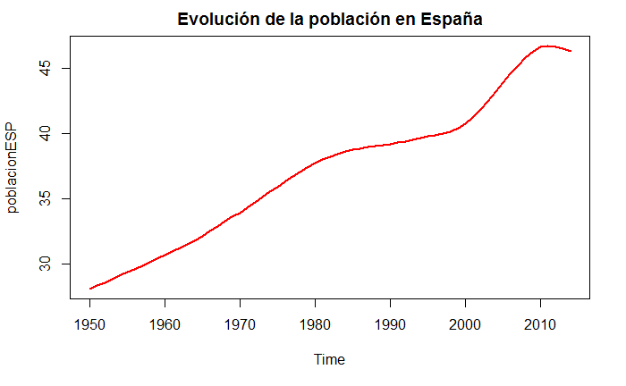

Poblacion de España

```r
    # install.packages("Quandl")
    require(Quandl)
    # creamos el API KEY para la conexión
    Quandl.api_key("LDgg4c7zsTgLLxyHj.")

    # obtenemos datos: serie temporal población en España
    poblacionESP<-Quandl("FRED/POPTTLESA148NRUG",type="ts")

    # podemos especificar las fechas de inicio y fin:
    # Quandl("FRED/GDPPOT", start_date="2005-01-03",end_date="2013-04-10",type="xts")

    plot(poblacionESP, main="Evolución de la población en España",type= "l",col="red",lwd=2)
```

La web de `Quandl` incluso facilita el propio script de R para el dato que buscas, por ejemplo mira aquí: https://www.quandl.com/data/FRED/GDPPOT-Real-Potential-Gross-Domestic-Product

## 3.6 Librería `quandmod`

Para obtener datos de bolsa y valores `quandmod` es una librería interesante que contienen la función `getSymbols()`. Esta función permite extraer de las webs de yahoo, FRED y alguna más los datos diarios de acciones, fondos e índices. Por desgracia *Google* bloqueó recientemente el acceso a *getSymbols*.

Para descargar un valor entre fechas es necesario conocer el TICKER del valor y usar la función como sigue, por cierto los datos se almacenan en un objeto `xts`.

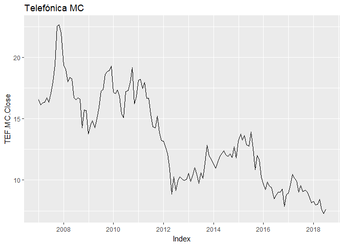

```r
    require(quantmod)

    acc1 <- getSymbols("TEF.MC",
                       src ="yahoo",
                       periodicity = "monthly",
                       warning= "FALSE",
                       adjust = TRUE,
                       auto.assign=FALSE)
    require(ggplot2)
    autoplot(Cl(acc1),main="Telefónica MC")
```

## 3.7 Librería `BatchGetSymbols`

Esta librería es similar a `quantmod`, pero para análisis de varios valores puede tener alguna ventaja al estructurar mejor los datos en una única *data frame*.

```r
    # esta librería no funcion con R nuevo
    library("BatchGetSymbols")
    # Cargamos varios tickers de empresas
    mis.valores <- c('MSFT','GOOGL','JPM','GE')

    # establecemos las fechas
    fecha.ini <- Sys.Date()-30
    fecha.fin <- Sys.Date()

    datosvalores<- BatchGetSymbols(tickers = mis.valores,
                             first.date = fecha.ini,
                             last.date = fecha.fin )
```

## 3.8 ustyc

El paquete `ustyc` permite la descarga de los datos de la curva de interes del Departamento del Tesoro de EE.UU. La curva de intereses es el tipo que un inversor recibiría por los bonos a diferentes vencimientos. Los valores de los rendimientos se basan en los precios de los instrumentos de deuda del gobierno de EE.UU. negociados en el mercado secundario.

Dado que estos bonos tienen un riesgo de incumplimiento mínimo, estos valores se utilizan comúnmente como puntos de referencia para rendimientos sin riesgo en los mercados financieros.

Usar el paquete ustyc es muy simple. Todo lo que necesita hacer es llamar a la función `getYieldCurve`. En el siguiente ejemplo, descargaremos la curva de rendimiento para el año 2017.

```r
    library(ustyc)
    # obtener lacurva de rendimiento
    my.yield.curve <- getYieldCurve(year = 2017)
    print(head(my.yield.curve$df))
```

```
##            BC_1MONTH BC_3MONTH BC_6MONTH BC_1YEAR BC_2YEAR BC_3YEAR
## 2017-01-03      0.52      0.53      0.65     0.89     1.22     1.50
## 2017-01-04      0.49      0.53      0.63     0.87     1.24     1.50
## 2017-01-05      0.51      0.52      0.62     0.83     1.17     1.43
## 2017-01-06      0.50      0.53      0.61     0.85     1.22     1.50
## 2017-01-09      0.50      0.50      0.60     0.82     1.21     1.47
## 2017-01-10      0.51      0.52      0.60     0.82     1.19     1.47
##            BC_5YEAR BC_7YEAR BC_10YEAR BC_20YEAR BC_30YEAR
## 2017-01-03     1.94     2.26      2.45      2.78      3.04
## 2017-01-04     1.94     2.26      2.46      2.78      3.05
## 2017-01-05     1.86     2.18      2.37      2.69      2.96
## 2017-01-06     1.92     2.23      2.42      2.73      3.00
## 2017-01-09     1.89     2.18      2.38      2.69      2.97
## 2017-01-10     1.89     2.18      2.38      2.69      2.97
##            BC_30YEARDISPLAY
## 2017-01-03             3.04
## 2017-01-04             3.05
## 2017-01-05             2.96
## 2017-01-06             3.00
## 2017-01-09             2.97
## 2017-01-10             2.97
```

## 3.9 Datos de Bitcoin y otras criptomonedas

Otra fuente de datos de interés son las nuevas criptomonedas y el Bitcoin (BTC).

### 3.9.1 `coinmarketcapr`

Uno de los paquetes más interesantes es `coinmarketcapr` con el que podemos descargar las series temporales de valoración de criptos que usa la web https://coinmarketcap.com/ y muchas funciones variadas de control del estado de mercado:

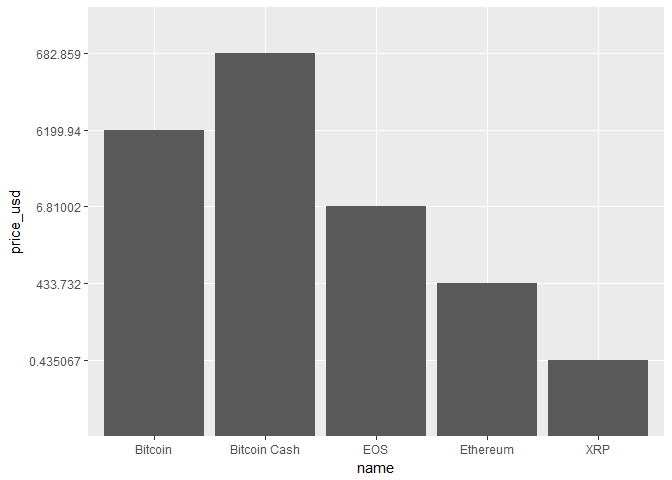

```r
    library(coinmarketcapr)
    # funcion plot_top_5_currencies
    # pinta el valor de las 5 primeras criptos en capitalización
    plot_top_5_currencies()
```

```r
    # funcion get_marketcap_ticker_all
    # nos da el precio actual de cada cripto frente al $ y BTC
    market_today <- get_marketcap_ticker_all()
    head(market_today[,1:8])
```

```
##             id         name symbol rank price_usd  price_btc
## 1      bitcoin      Bitcoin    BTC    1   6201.83        1.0
## 2     ethereum     Ethereum    ETH    2   433.626  0.0700331
## 3       ripple          XRP    XRP    3  0.435309 0.00007030
## 4 bitcoin-cash Bitcoin Cash    BCH    4    682.21   0.110181
## 5          eos          EOS    EOS    5    6.8006 0.00109834
## 6     litecoin     Litecoin    LTC    6   76.4711  0.0123505
##   X24h_volume_usd market_cap_usd
## 1    3613890000.0   106330530396
## 2    1398500000.0  43641581078.0
## 3     179086000.0  17091295547.0
## 4     325895000.0  11756669900.0
## 5     557137000.0   6094354236.0
## 6     253511000.0   4387149565.0
```

### 3.9.2 `RBitcoin`

Otro paquete que vale la pena mencionar es [RBitcoin](https://github.com/jangorecki/Rbitcoin). Permite el acceso a los datos comerciales de varias casa de cambio de Bitcoin. Vamos a mostrar un ejemplo simple de importación de datos desde el exchange de intercambio [kraken](https://www.kraken.com/).

```r
    #install.packages("Rbitcoin", repos=c("https://jangorecki.gitlab.io/Rbitcoin","https://cran.rstudio.com"))

    library(Rbitcoin)
    # ver precios en exchanges
    market <- "kraken"
    #currency_pair <- c("BTC","EUR")
    currency_pair <- c("LTC","EUR")
    ticker <- market.api.process(market, currency_pair, "ticker")
    ticker
```

```
##    market base quote           timestamp market_timestamp  last     vwap
## 1: kraken  LTC   EUR 2018-07-12 14:56:38             <NA> 65.08 65.31476
##      volume   ask   bid
## 1: 8531.159 65.23 65.09
```

```r
    # CONVERSION DE VALORES
    fromBTC(1) # el precio actual de BTC en USD
```

```
## [1] 6192.334
```

```r
    fromBTC(1, "EUR") # el precio actual de BTC en euros
```

```
## [1] 5293.806
```

```r
    toBTC(150, "EUR") # convertir 150 EUROS a BTC
```

```
## [1] 0.02833707
```

```r
    # acceso a la blockchain
    # a wallet
    monedero <- blockchain.api.process('1A1zP1eP5QGefi2DMPTfTL5SLmv7DivfNa')
    str(monedero)
```

```
## Classes 'data.table' and 'data.frame':   1 obs. of  10 variables:
##  $ location      : chr "blockchain"
##  $ action        : chr "Single Address"
##  $ timestamp     : POSIXct, format: "2018-07-12 14:57:08"
##  $ currency      : chr "BTC"
##  $ hash          : chr "62e907b15cbf27d5425399ebf6f0fb50ebb88f18"
##  $ address       : chr "1A1zP1eP5QGefi2DMPTfTL5SLmv7DivfNa"
##  $ n_tx          : int 1283
##  $ total_received: num 66.9
##  $ total_sent    : num 0
##  $ final_balance : num 66.9
##  - attr(*, ".internal.selfref")=<externalptr>
```

```r
    # Acceso a las transacciones
    tx <- blockchain.api.process('e5c4de1c70cb6d60db53410e871e9cab6a0ba75404360bf4cda1b993e58d45f8')
    str(tx, max.level=1)
```

```
## List of 10
##  $ location    : chr "blockchain"
##  $ action      : chr "Single Transaction"
##  $ timestamp   : POSIXct[1:1], format: "2013-12-22 21:22:14"
##  $ currency    : chr "BTC"
##  $ double_spend: logi FALSE
##  $ inputs      :Classes 'data.table' and 'data.frame':   1 obs. of  3 variables:
##   ..- attr(*, ".internal.selfref")=<externalptr>
##  $ hash        : chr "e5c4de1c70cb6d60db53410e871e9cab6a0ba75404360bf4cda1b993e58d45f8"
##  $ tx_index    : int 45125549
##  $ out         :Classes 'data.table' and 'data.frame':   2 obs. of  3 variables:
##   ..- attr(*, ".internal.selfref")=<externalptr>
##  $ size        : int 258
```

### 3.9.3 `coindeskr`

Otro paquete interesante es `coindeskr`, que extrae de la web de noticias mas famosa del sector https://www.coindesk.com/ el precio del bitcoin y otras cosas interesantes. La informeación de la libraría está en: https://cran.r-project.org/web/packages/coindeskr/coindeskr.pdf

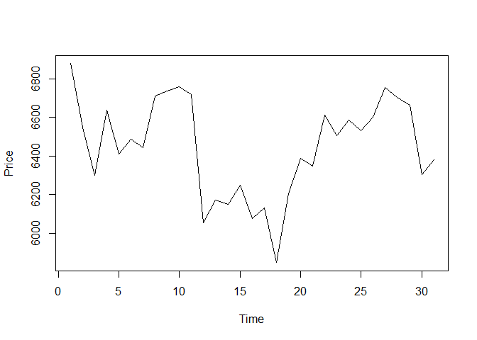

```r
    # Intalamos el paquete
    #install.packages('coindeskr')
    library(coindeskr) #R-Package connecting to Coindesk API

    # obtenemos el precio de los ultimos 31 días (ultimo mes)
    last31 <- get_last31days_price()
    # pintamos le resultado
    plot.ts(last31)
```

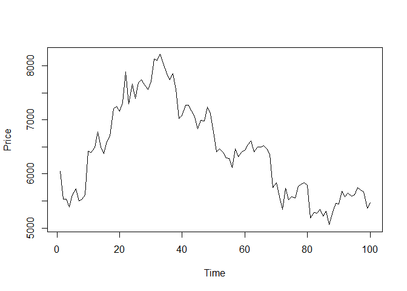

```r
    # obtenemos los precios historicos del cambio BTC EUR
    precios100_dias<-get_historic_price(currency = "EUR", start = Sys.Date() - 100,end = Sys.Date() )
    plot.ts(precios100_dias)
```

### 3.9.4 Enlaces de datos

Algunas paginas web dan un servicio directo de descarga de datos en formato csv, por ejemplo los datos de cambi de BTC están disponibles en este sistema en: http://data.bitcoinity.org/markets/price_volume/all/USD?t=lb&vu=curr

De esta página hemos descargado el fichero *bitcoinity_data.csv* con los precios históricos y volumen de BTC.

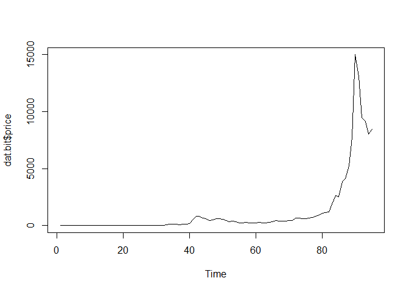

```r
    #Leemos el fichero
    require(rio)
    dat.bit<-import("bitcoinity_data.csv")
    plot.ts(dat.bit$price)
```

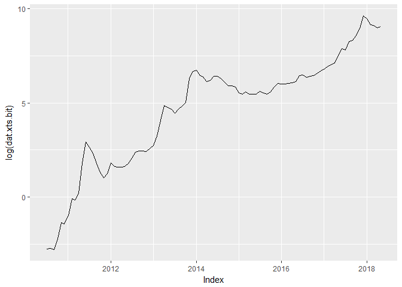

```r
    # Como vemos no coge bien las fechas por lo que debemos hacer una conversión forzada
    # usando la libraría xts.
    library(xts)
    dat.xts.bit <- xts(dat.bit$price, order.by=as.Date(dat.bit$Time, "%Y-%m-%d %R"))
    # pintamos el logaritmo de la serie para comprender mejor los cambios de escala
    autoplot(log(dat.xts.bit))
```

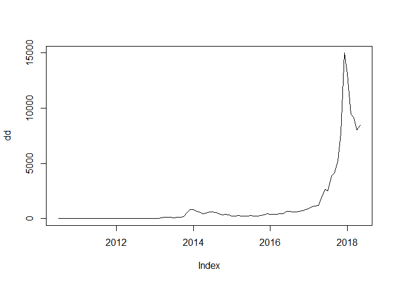

```r
    #otra opcion es usar zoo
    require(zoo)
    dd<- read.zoo(dat.bit[,1:2],header = TRUE, format = "%Y-%m-%d %R")
    plot(dd)
```

```r
    # agregamos a valores mensuales por año yearamon
    dd.mes<-as.zooreg(aggregate(dd, as.yearmon,max),freq=12)
    tail(dd.mes)
```

```
##  dic 2017  ene 2018  feb 2018  mar 2018  abr 2018  may 2018
## 14973.449 13070.416  9448.033  9156.124  8001.071  8446.214
```

# 4 GRÁFICAS DE SERIES TEMPORALES

Hemos visto como manejar objetos de tiempo en R, con las clases: `Date`, `POSIXlt` y `POSIXct`, estas clases nos facilitan el trabajo de fechas, pero las series temporales son algo más complejas pues además del fechado está el otro par del conjunto que lo forma el valor.

En las series de intervalo regular nos podemos olvidar del fechado para trabajo analítico y quedarnos solo con el valor y el orden cronológico de dichos datos. Esto facilita el trabajo y amplia las posibilidades de cálculo.

Vamos a ver en este capitulo cómo pintar objetos de serie temporal en R para producir desde gráficos sencillos a otros complejos con tratamiento implicito de los datos como los estacionales o los de ACF.

## 4.1 Funciones básicas de trazado de series temporales

Cuando usamos el comando `plot()` para representar series temporales R reconoce automáticamente el origen de los datos y ejecuta la funcion `plot.ts()`. Esta función adapta los ejes de abcisas al formato de fecha que tenga la serie temporal así como algunas otras caracteristicas gráficas.

Otra de las funciones que permiten dibujar series temporales es `ggplot`, y en concreto el comando `autoplot()`.

```r
    # Vamos a leer unos datos temporales de la FRED
    # para su representación grafica posterior:
    # desempleo datos ESP trimestrales
    desESP <- getSymbols("LRUN64TTESQ156N",
                       src ="FRED",
                       warning= "FALSE",
                       adjust = TRUE,
                       auto.assign=FALSE)
    # precio vivienda ESP datos trimestrales
    pcasasESP <- getSymbols("QESN628BIS",
                       src ="FRED",
                       warning= "FALSE",
                       adjust = TRUE,
                       auto.assign=FALSE)

    # Unimos las dos variables
    datosESP<- cbind(desESP,pcasasESP)
    # Eliminamos las filas sin ambos datos
    datosESP<-datosESP[complete.cases(datosESP),]
```

## 4.2 Gráficas estandar

Describimos las funciónes sencillas para pintar grafics temporales. Es un asunto delicado, pues nos encontraremos que en muchas ocasiones, las funciones habitaules de trazado no pintan las graficas correctamente, o no interpretan las fechas que están almacenadas en lso objetos `ts`, `xts`, u otros. En ocasiones manejaremos dataframes, que son los objetos más comunies, y no sabremos cómo pintar las fechas correctamente, bien porque están en los nombres de fila o porque proceden de un objeto xts. Estas cuestiones las intentaremos acalarar en este apartado que será consulta obligada para el que se inicia en series temporales.

### 4.2.1 `plot.xts`

El formato más completo para trabajar con series temporales es `xts`, pues los datos de objetos `ts` están más limitados, por ejemplo requieren datos de frecuencia uniforme y sin huecos mientras que `xts`no.

Por esto la forma habitual de pintar una grafica temporal es como `plot.xts()`, esta función produce gráfias por defecto que detectan las fechas y pinta correctamente los datos.

```r
    # pintamos una grafica como plot.xts
    plot.xts(datosESP)
```

[output not shown]

### 4.2.2 `autoplot`

Otro tipo de grafico comodín al que recurrir con frecuiencia es `autoplot`. Es una versión simplificada de `ggplot` que no necesita de la definición detallada de los parámetros y por tanto es más sencilla de usar que la función original de la libreria `ggplot2`. Cuando la funcion detecta una serie temporal la función real que ejecuta es `autoplot.zoo()`.

```r
    # pintamos una grafica como plot.xts
    autoplot(datosESP)

    #Calculamos 3 funciones de pronostico de los datos a h=10
        y <-forecast(datosESP$desempleo, h=10) # ets pronostico
        y2<-rwf(datosESP$desempleo,h=10,drift=TRUE)
        y3<-naive(datosESP$desempleo,h=10)

    # pintamos los 3 pronosticos en la misma gráfica
        autoplot(y, PI=T) +  #PI=false indica la banda no se muestra
            autolayer(y2, PI=F, col="red") + # añadir capas a autoplot
            autolayer(y3, PI=F, col="green")
```

[output not shown]

### 4.2.3 `plot.zoo`

Las funciones de trazado de `zoo`para serires temporales son de las mejores y están expresamente pensadas para crear graficas claras y atractivas.

```r
    # Muestra de plot.zoo
    plot.zoo(datosESP,col=c("blue","red"), xlab="Año")
```

[output not shown]

### 4.2.4 Otras funciones gráficas

Existen multitud de librerías gráficas en R. Para usar con serie temporales suelen ser apropiadas las librerías financieras que contienen funciones grñaficas adaptadas y en algún caso muy buenas, tambien otras librerías especializadas en graficos interacticos como dygraphs, vemos algunas de ellas.

Las funciones `chartSeries` y `barChart` de la librería `quandmod`, o la función `chart.TimeSeries` de la librería `PerformanceAnalytics` suelen dar buenos resultados vamos a ver ejemplos para nuestro curriculo.

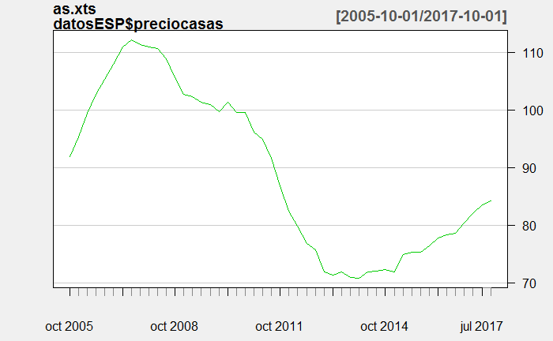

chartseries

[figure not shown]

chart.TimeSeries

```r
    # Ejemplo de graficas
    # Librería quantmod
    require(quantmod)
        chartSeries(datosESP$preciocasas, TA=NULL,theme=chartTheme('white'))
       # barChart(datosESP$preciocasas,TA=NULL,theme=chartTheme('white'))

    # Librería PerformanceAnalytics
    require(PerformanceAnalytics)
    chart.TimeSeries(datosESP)

    # Libraría dygraph, interactiva
    # install.packages("dygraphs")
    require(dygraphs)
    dygraph(datosESP)
```

## 4.3 Gráficas estacionales

La librería `forecast` contiene una funcion para representar *graficas estacionales* usando `ggseasonplot()`o también `seasonplot()`. Lo que hacen estas funciones es trazar una línea para cada ciclo completo y superponer todos juntos en la grafica. Es decir, para el caso de graficas con ciclos anuales, nos pintaría cada año superpuesto.

Una gráfica estacional es similar a una gráfica de tiempo excepto que los datos se dibujan en las “temporadas” individuales en las que se observaron los datos.

Estas funciones tienen una variante interesante que convierte los datos a coordenadas polares, donde el eje de tiempo es circular en lugar de horizontal. Para cambiar este sistema es suficiente con cambiar el argumento polar a VERDADERO.

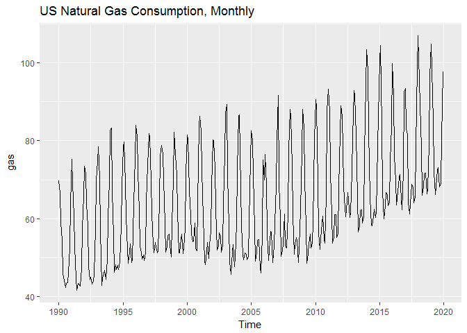

```r
    require(ggplot2)  # para las graficas
    require(forecast) # para el ggseasonplot

    require(Quandl)   # para los datos
    # Quandl.api_key("lalala")
    # obtenemos los datos de población de España
    # vamos a usar datos de consumo de gas en USA
    gas<-Quandl("EIA/STEO_NGTCPUS_M", api_key="ybWqPvdv3r6bfrsNFkbq", type="ts")
    # podemos especificar las fechas de inicio y fin:
    autoplot(gas,main="US Natural Gas Consumption, Monthly")
```

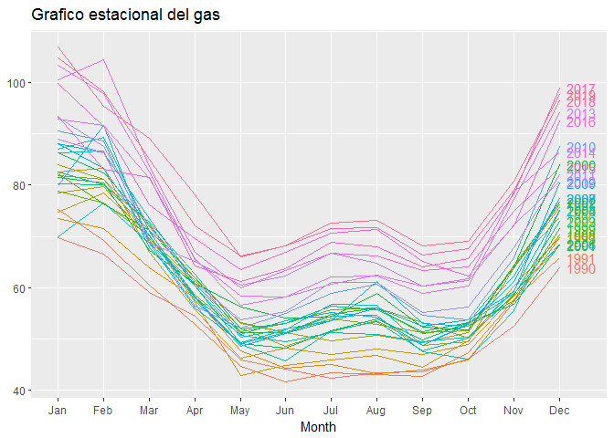

```r
    # Grafica estacional
    ggseasonplot(gas,year.labels=TRUE, main="Grafico estacional del gas")
```

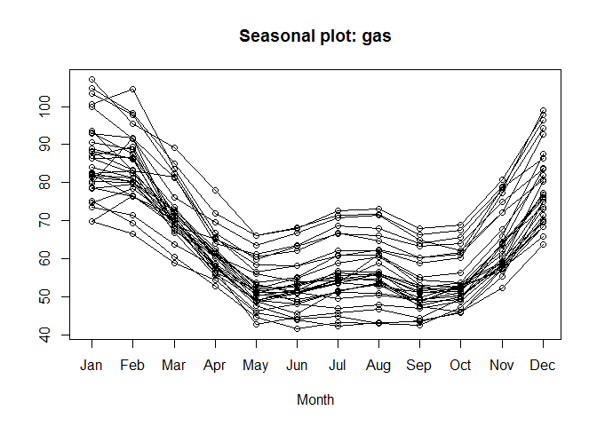

```r
    # Grafcia estacional en ByN
    seasonplot(gas)
```

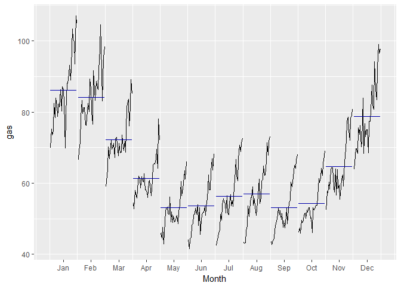

```r
    # Grafica estacional  sin superposición
    ggsubseriesplot(gas)
```